# DS Project_2

Tania Bobbili

2025-11-10

## 1. Introduction

My first dataset provides health information on each US county and my second dataset is a table that I plan to web scrape a table that provides information on the number of those in poverty for each US county. I got the first data set from an organization called [County Health Rankings](https://www.countyhealthrankings.org/health-data/methodology-and-sources/data-documentation/national-data-documentation-2010-2023) and the second dataset comes from the [USDA government website](https://data.ers.usda.gov/reports.aspx?ID=4040). I picked these datasets so that I could explore the different factors around health. I will be investigating the relationship between variables such as obesity, low birthweight rates, poverty, smoking habits in each county, average amount of days spent in poor mental health, and percent of residents in poor health.

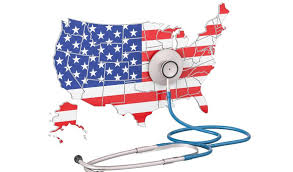

## Data Preparation

I obtained my first dataset through a website where I was able to easily download it. However, when I tried to import it, I realized it wasn’t a csv file so I went on a website to convert the file. Then, when I tried to import it, the data got messed up so what I ended up doing was going into the Excel file and copying the table into google sheets so that I could then export that into a .csv file. I created 2 new variables because I needed to create categorical variables. I calculated the median of percentage of smokers across all counties and depending on if the value for a county was higher or lower, it would either be a “heavy smoker” county or a “light smoker” county. I did the same thing with obesity rates. For my second dataset, I tried to use html to easily web scrape it but I couldn’t get it to work so I manually scraped it into a Google Sheets and then imported it to R. Then. I joined the 2 datasets. Also, when joining the datasets there was a duplicate of each row which was inflating the data so I used join <-distinct(join) in order to make sure each row was unique. After the dataset was joined, I realized that there were some rows that randomly had a missing value in the county column so I got rid of that. There are 3041 observations.

```r
US_COUNTY_HEALTH <- read.csv("US_COUNTY_HEALTH.csv")
Poverty <- read.csv("Poverty.csv")

library(tidyverse)
county_health <- data.frame()

for (i in 1:nrow(US_COUNTY_HEALTH)) {
  if (!any(is.na(US_COUNTY_HEALTH[i, ])))
    {
    county_health <- rbind(county_health, US_COUNTY_HEALTH[i, ])
  }
}

median(county_health$perc_smokers)
```

[output not shown]

```r
median(county_health$obesity)
```

[output not shown]

```r
  county_health<- as_tibble(county_health) |>
    rename(perc_smokers = `X..Adults.Reporting.Currently.Smoking`, low_birth = `X..Low.Birthweight`, obesity = `X..Adults.with.Obesity`, poor_health = `X..Fair.or.Poor.Health`, poor_mental = `Average.Number.of.Mentally.Unhealthy.Days`) |>
  mutate(smoking_habits = if_else(perc_smokers > 20, "Heavy Smokers", "Light Smokers")) |>
    mutate(obesity_distribution = if_else(obesity >37, "Higher Obesity Area", "Lower Obesity Area"))



join <- left_join(county_health, Poverty, by = c("County", "State"))
join <- distinct(join)
join <- join[join$County != "" & !is.na(join$County), ]
```

## Variable Descriptions

```r
join <- join |>
rename(perc_pov = Perc..in.pov)

join$FIPS.x <- NULL
join$perc_smokers <- NULL
join$FIPS.y <- NULL
join$RUC.Code <- NULL
join$obesity <- NULL


library(knitr)
variable_table <- data.frame(Variable = c("County", "State", "smoking_habits", "low_birth", "obesity_distribution", "poor_health", "perc_pov", "poor_mental"),
Type = c("character", "character", "character", "numeric", "character", "numeric", "numeric", "numeric"),
  Description = c( "Name of the county.", "Name of the state the county belongs to.", "Determines if county has higher percentage of smokers", "Percentage of live births with low birthweight (<2500g).", "Determines if county has a higher amount of obese residents", "Percentage of adults reporting poor health.", "Percentage of population living in poverty.", "Percentage of population with poor mental health"))

kable(variable_table, caption = "Variable Information for County Health Information")
```

Variable Information for County Health Information

[output not shown]

# Graph 1

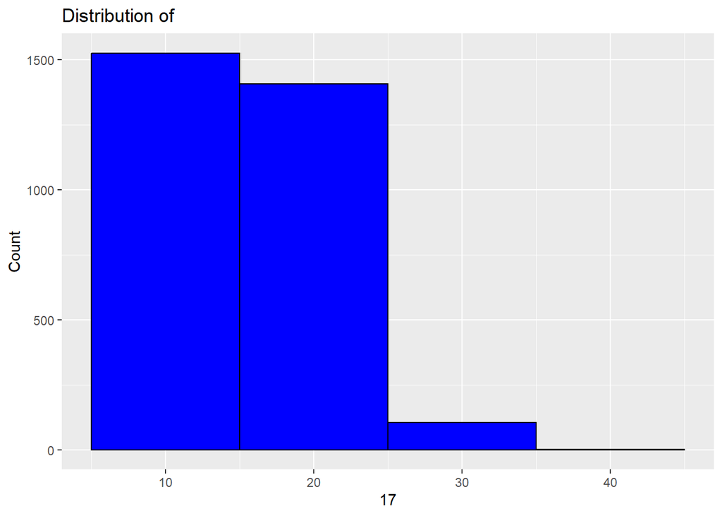

```r
library(ggplot2)
univariate = function (variable, color = "chocolate"){
  variable_plot = ggplot(join)

variable_plot + geom_histogram(aes(x =variable), binwidth = 10, fill = color, col = "black") +   labs( x = paste(variable), y = "Count", title = "Distribution of", variable)

}

univariate(join$poor_health, "blue")
```

The distribution is skewed right. The median of percentage in poor health is 15 and the average is 16.19 .

# Graph 2

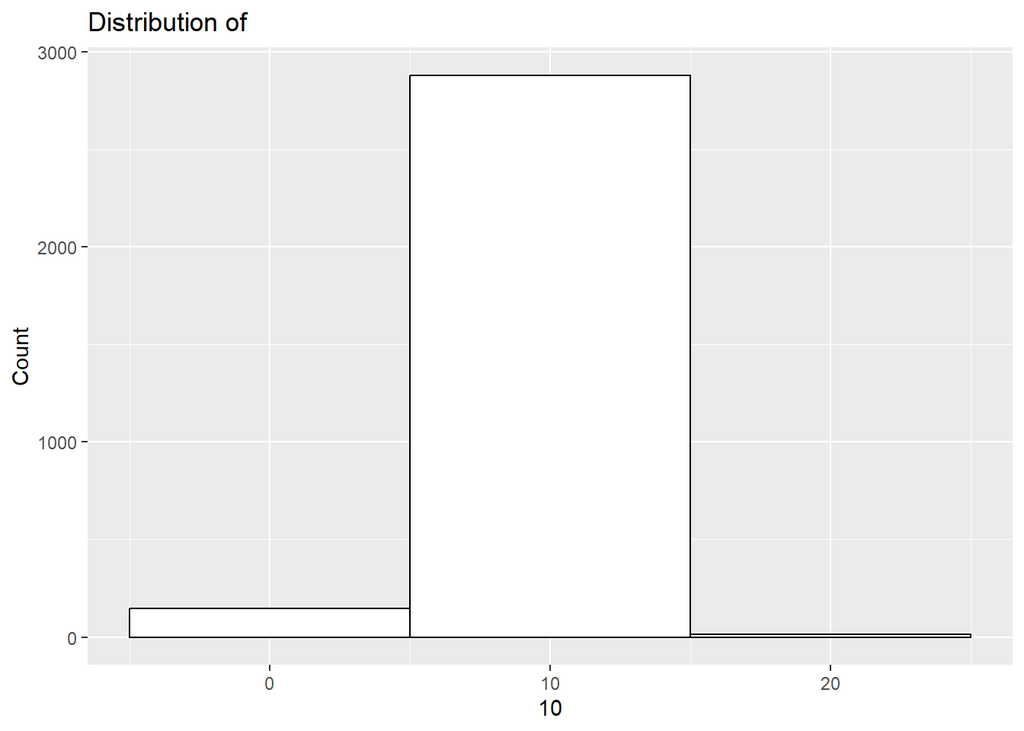

```r
univariate(join$low_birth, "white")
```

The distribution is skewed right. The median of percentage of low weight births is 8 and the average is 8.21 .

# Graph 3

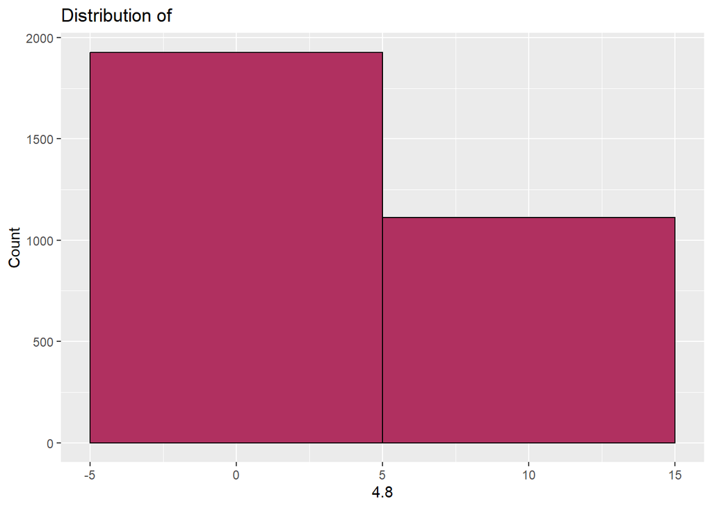

```r
univariate(join$poor_mental, "maroon")
```

# Graph 4

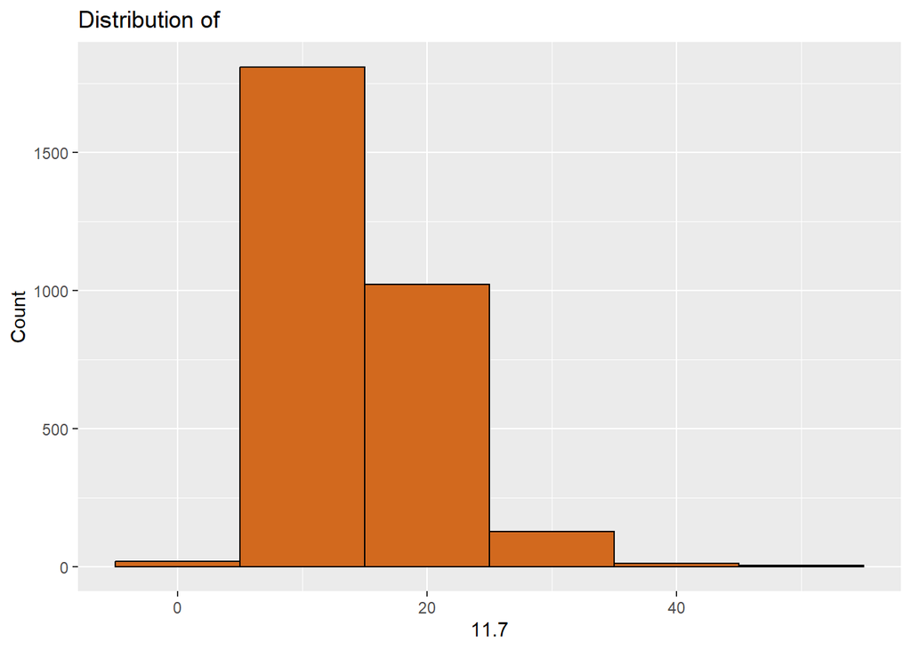

```r
univariate(join$perc_pov)
```

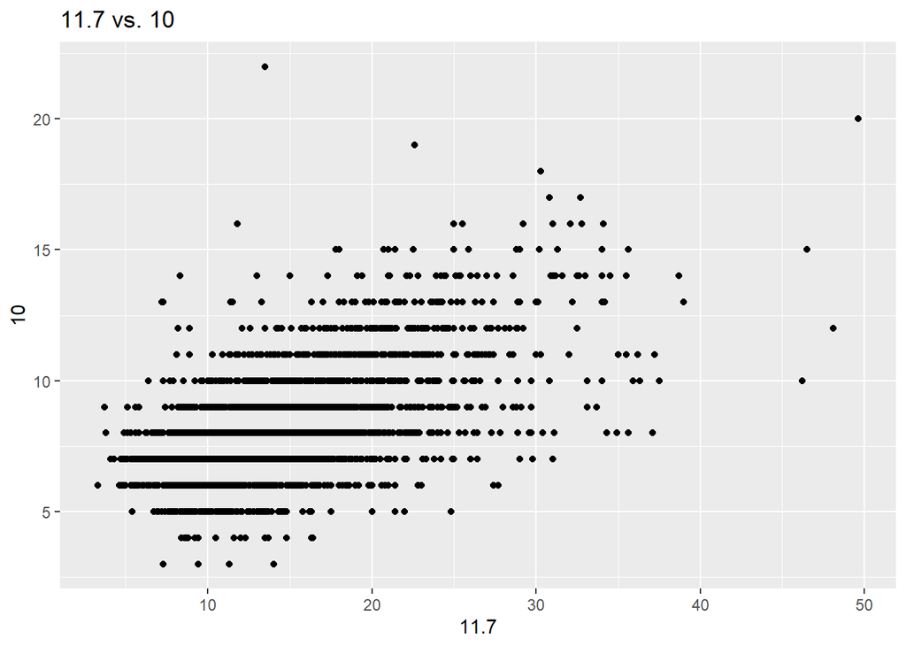

```r
multivariate_num = function (x,y, color = "chocolate"){
  variable_plot = ggplot(join)

variable_plot + geom_point(aes(x =x, y = y), fill = color, col = "black") +   labs( x = paste(x), y = paste(y), title = paste(x, "vs.", y))

}
multivariate_num(join$perc_pov, join$low_birth)
```

# Graph 2

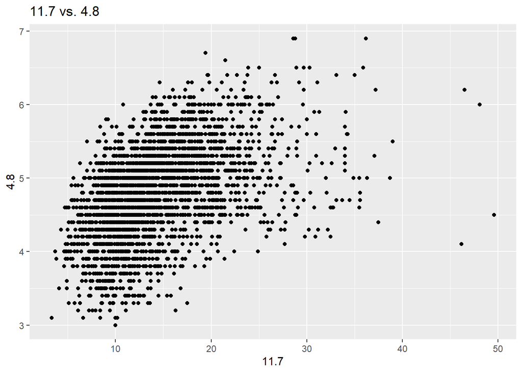

```r
multivariate_num(join$perc_pov, join$poor_mental)
```

# Graph 3

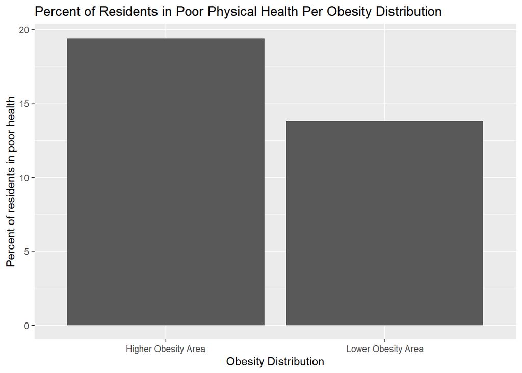

```r
variable_plot <- ggplot(join, aes(x = obesity_distribution, y = poor_health))  + geom_bar(stat = "summary", fun = "mean") + labs(x = "Obesity Distribution", y = "Percent of residents in poor health",title = "Percent of Residents in Poor Physical Health Per Obesity Distribution")
variable_plot
```

Higher obesity counties tend to have a higher percentage of residents in poor health compared to the lower obesity counties. The average amount of residents in poor physical health in a high obesity area is 19.38 and the average amount of residents in poor physical health for a low obesity area is 13.78